# Clustering

### J.A.

In this lab, we will focus on the problem of clustering or finding which objects belong to the same group or cluster. Clustering is the task of finding structure in the data. The most difficult part in this is verifying whether indeed there is structure in the data; this problem we refer to as *cluster validation*.

## Hierarchical Clustering

In hierarchical clustering you need to choose two parameters: a dissimilarity measure and a type of linkage. We will be using Euclidean distance as a measure for dissimilarity, whereas common linkage types are *complete*, *single*, or *average*.

**Exercise 1**. Read in the file 'clust14.txt' which consists of 140 objects with two features, and create a 2D scatter plot. How many clusters do you think there are in the data? Generate a dendrogram using complete linkage by calling **linkage()** and **dendrogram()** from **scipy.cluster.hierarchy**. To perform clustering we still need to decide upon the number of clusters which in this case we will set to *k = 14*. Use **AgglomerativeClustering()** from **sklearn.cluster** to cluster the data accordingly and obtain object labels. Finally, use the object labels you've obtained in order to create a 2D scatter plot as before, however assign different colors to the clusters.

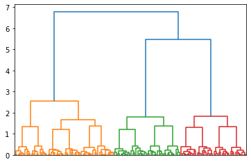

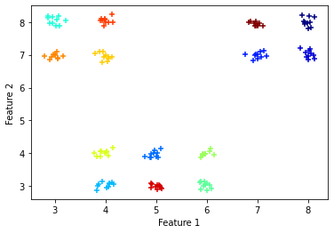

**Exercise 2**. Building upon the previous exercise, construct a fusion curve (hint: the output of function **linkage()** contains the distances of the vertical stems in the dendrogram, particularly in one of its columns; read documentation to find out which column). Use these by first reversing the order of elements, then plot only the first 16 values. Where would you cut the dendrogram based on this plot, and how many clusters would be formed? Change *k* to this value and generate a new scatter plot showing the clusters in different color as you have done before.

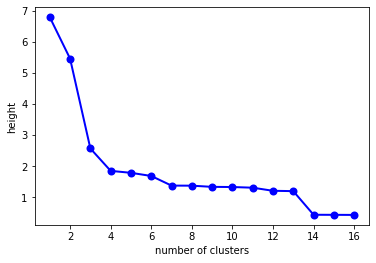

**Exercise 3**. Read in the file 'parallelclust.txt', and create a 2D scatter plot. How many clusters do you see? Describe their shape. Construct a dendrogram using complete linkage. Set the number of clusters to two and show a 2D scatter plot with different colors assigned to the different clusters. Repeat the clustering, however this time change the linkage type to *single*. Is the scatter plot now as expected? Had we been working in higher dimensions, could we have foreseen which linkage type to select?

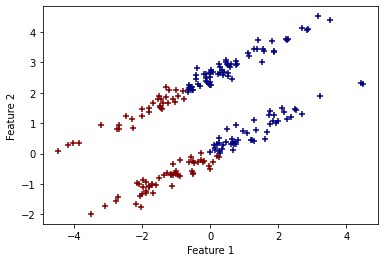

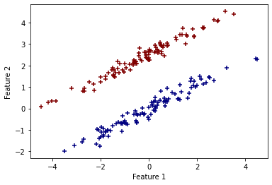

**Exercise 4**. Read in the data file 'gaussianclust.txt' and create a 2D scatter plot. How many clusters are there? Based on their shape, which linkage type would you choose? Construct the dendrogram and perform clustering using the linkage type you have chosen. Show your result in the form of a scatter plot.

**Exercise 5**. Read in the file 'clust3.txt' which contains a dataset consisting of 150 objects in 2 dimensions. Generate a scatter plot and deduce the number of available clusters. The function **davies_bouldin_score()** computes the Davies-Bouldin index for a given clustering outcome and is found in the module **sklearn.metrics**. The inputs to the function are a given dataset and the cluster labels. Use **davies_bouldin_score()** within a for loop to obtain an array of scores, one score for each value of `k = 2, 3, ..., M`. Plot the Davies-Bouldin index as a function of the number of clusters `k` for the given dataset using complete linkage with the maximum number of clusters to try out being `M = 10`. What is the optimal number of clusters to use for this dataset? Does this agree with what you would expect from visual inspection of the scatter plot? Repeat the above for 'clust14.txt' and plot the Davies-Bouldin index curve (use `M = 20`, complete linkage). How many clusters does the curve suggest, three or fourteen? Finally, do the same for 'parallelclust.txt'. What does the curve suggest in this case?

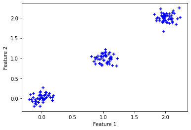

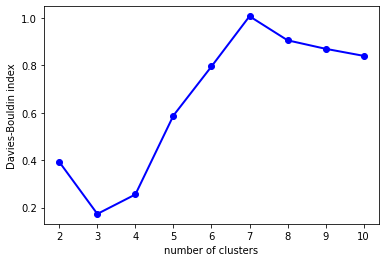

## K-means Clustering

**Exercise 6**. Read in the file 'gaussianclust.txt' and create a 2D scatter plot. Run the k-means algorithm with k = 2 using **KMeans()** form **sklearn.cluster**. Set the maximum number of iterations `max_iter` to 100 and the number of initializations `n_init` to 10. You can access the cluster labels using the attribute `labels_` after fitting the model. The cluster centers can also be accessed using the attribute `cluster_centers_`. Create a scatter plot of the two clusters given in different color along with their centroids.

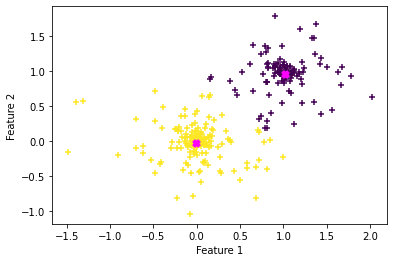

**Exercise 7**. Read in the file 'clust3.txt' and repeat the previous exercise using this dataset, however set k = 3.

**Exercise 8**. Read in 'parallelclust.txt' and repeat the previous exercise using this dataset with a suitable number of clusters, k. Do you ever achieve the expected result? Why or why not?

## Gaussian Mixture Model

Clustering based on a Gaussian mixture model uses the expectation-maximization (EM) algorithm to estimate the parameters of the Gaussian models. In this section, we shall investigate how to use this clustering method in practice.

**Exercise 9**. Read in 'clust3.txt' which we expect to contain three clusters. Sklearn provides **GaussianMixture()** which implements the mixture of Gaussians method (**sklearn.mixture** module). Set the number of clusters to 3 and `covariance_type='full'`, and fit the model to the data to obtain cluster labels using the **fit_predict()** method. Create a scatter plot of the data using different colors for the different clusters.

**Exercise 10**. Repeat the previous exercise using the dataset found in 'parallelclust.txt'; the only change required is to set the number of clusters to 2. Recall that k-means failed to converge to the expected result. Does the mixture of Gaussians method succeed?

**Exercise 11**. Read in the file 'clust3.txt'. Run the mixture of Gaussians clustering within a *for* loop for each of `n_components` = 1,2,...,9 and obtain the Bayesian information criterion for each case using the method **bic()** on the fitted model. Plot the BIC values as a function of the number of clusters. Judging by the plot, what is the optimal number of clusters to choose for this dataset?

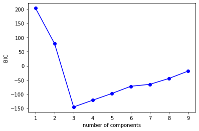

## Self-Organizing Maps

SOMs are iterative methods that construct a topographic mapping from a high dimensional feature space (data space) to a lower dimensional map space which is two dimensional in most cases. This latter space consists of a grid of cluster centers each of which has a corresponding position in the original data space. Cluster centers that are neighbors in data space are also neighbors in map space. As the self-organizing map is trained, the centers in data space move around so as to cover the data in an optimal manner. One may then view map space in order to gain insight on the structure of the data in the original data space.

**Exercise 12**. Load the iris dataset using **load_iris()** from **sklearn.datasets** and create a scatter plot using the last two features (note: this dataset was also used in the previous lab). Then, build a self-organizing map with size (10,10) using **minisom**. You may use the code below to do so. Note: the resulting image shows the U-matrix (distance map to neighbors) which helps us decide on the number of clusters in the data.

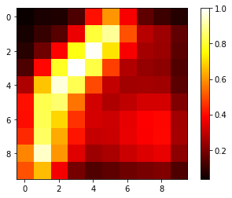

```python
#%pip install minisom        #minisom is from: https://github.com/JustGlowing/minisom

from minisom import MiniSom
from sklearn import datasets

iris = datasets.load_iris()
X = iris.data[:,-2:]

n_neurons = 10
m_neurons = 10

som = MiniSom(n_neurons, m_neurons, X.shape[1], sigma=1.5, learning_rate=0.05, neighborhood_function='gaussian')
som.pca_weights_init(X)
som.train(X, 5000, verbose=False)

plt.imshow(som.distance_map().T, cmap='hot')
plt.colorbar()
plt.show()
```

**Exercise 13**. Repeat the previous exercise using 'clust3.txt' which clearly consists of three clusters. Does the U-matrix suggest there are three clusters present?

## Fuzzy c-means

Fuzzy c-means is a form of weighted k-means wherein a membership value is assigned to each cluster. We will next apply fuzzy c-means to segment an image of a tissue section taken from a patient.

**Exercise 14**. Use **imread()** (module: **matplotlib.pyplot**) to read in the image 'tissue.png', and show the image using **imshow()**.

A color image is made up of three matrices (one for the red channel, one for blue, and one for green): check that the dimensions of the image are 1544 x 2080 x 3. Next, place the image's red, green, and blue channels (2D arrays) as single columns in a matrix X (eg using numpy's **ravel()** and **stack()**).

To perform pixel classification using fuzzy c-means, use **FCM()** (from: **fcmeans**; https://pypi.org/project/fuzzy-c-means/). In the arguments of **FCM()**, `n_clusters` is the number of clusters desired, `max_iter` is the maximum number of iterations to perform, and the exponent `m` controls the fuzziness level. The input data X should be in standard form, that is features as columns and objects as rows. In this case, we have three features corresponding to the three color channels R, G, and B. The number of objects is the number of pixels in the image (each pixel is an object that needs to be classified). Set the number of clusters to 4 since we expect the different clusters to cover the white background, purple nuclei, brown DAB stain of basal cells, and pink cytoplasm. The membership value of every pixel to each of the four clusters can be accessed through the attribute `u` of the trained model. Derive the four membership images by reshaping these values according to the size of the image (ie rows and columns).

Finally, show each of these four images (pmap0, ..., pmap3) along with their pseudo-colored versions side-by-side as illustrated below.

```python
'''
pmap0_pseudo_colored = image * np.repeat(pmap0,3).reshape(pmap0.shape[0], pmap0.shape[1], 3)

fig, ax = plt.subplots(1, 2, figsize=(10,5))
ax[0].imshow(pmap0, cmap='gray')
ax[1].imshow(pmap0_pseudo_colored)
plt.show()
''';
```

```
WARNING:absl:No GPU/TPU found, falling back to CPU. (Set TF_CPP_MIN_LOG_LEVEL=0 and rerun for more info.)
```

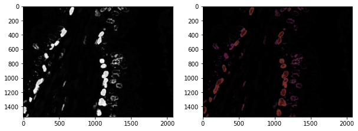